# Francesco/Esteves/Valle Model — Análise Completa com Benchmarks Setoriais

## 12. Distribuição de retornos e correlação

```
[INFO]: Plot saved → /media/toni/Dados/Git/ssd-multi/src/output/tafmssd-sectors/return_dist_models.pdf
```

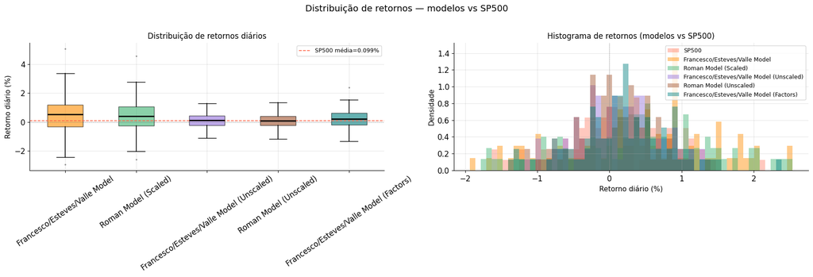

**Distribuição de retornos diários**

```
[INFO]: Plot saved → /media/toni/Dados/Git/ssd-multi/src/output/tafmssd-sectors/correlation_all.pdf
```

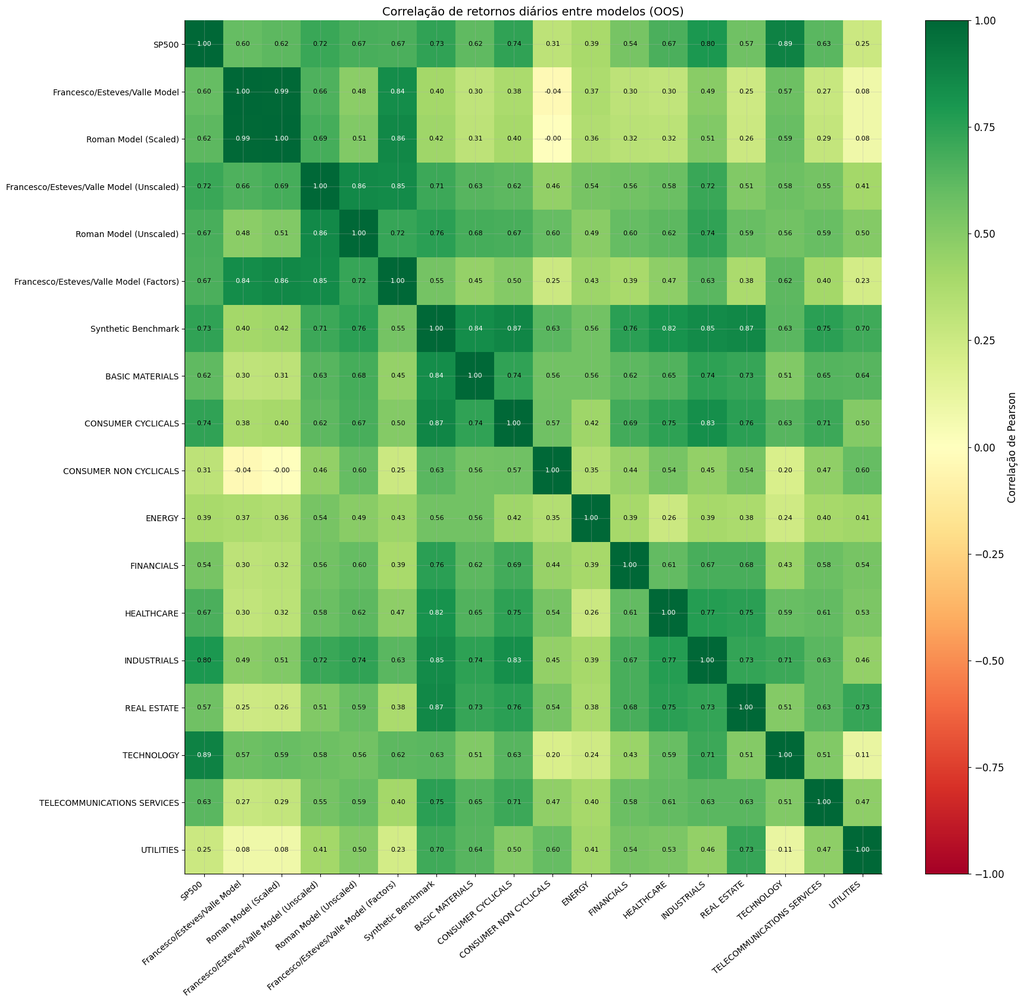

**Matriz de correlação**

O heatmap revela as correlações entre os retornos diários de todos os modelos e setores. Correlação baixa do Francesco/Esteves/Valle Model com um setor individual indica que o portfólio não replicou aquele benchmark — provavelmente porque diferentes setores foram binding em diferentes janelas de treino, gerando um portfólio com exposição setorial diversificada ao longo do tempo. Correlação moderada com o Synthetic Benchmark é o padrão esperado: alta correlação indicaria que o portfólio rastreia o envelope setorial (comportamento de clone); correlação muito baixa indicaria independência quase total — estratégia de diversificação agressiva que maximiza o gap em relação ao benchmark. O bloco de correlações entre setores identifica grupos que compartilham ciclos (ex: Financials e Real Estate), o que pode criar instabilidade nas restrições SSD quando ocorre rotação entre eles. Alta correlação entre Francesco/Esteves/Valle Model e Roman Model sugere que os dois convergem para portfólios similares apesar de benchmarks distintos — evidência de robustez da abordagem SSD; baixa correlação indica que o benchmark realmente diferencia o portfólio resultante.

## 13. Retornos em janela deslizante (21 dias)

```
[INFO]: Plot saved → /media/toni/Dados/Git/ssd-multi/src/output/tafmssd-sectors/rolling_returns.pdf
```

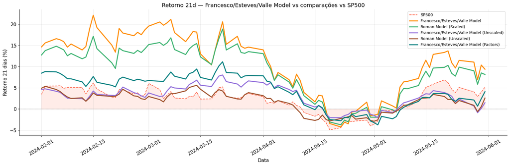

**Retornos em janela deslizante de 21 dias**

A série de retornos em janelas de 21 dias suaviza o ruído diário e destaca tendências de médio prazo, revelando o comportamento do portfólio no horizonte temporal que coincide com a frequência de rebalanceamento. Um portfólio SSD-robusto deve mostrar retornos mensais raramente muito negativos: a proteção de downside garantida in-sample deve ser visível em escala mensal, não apenas nos retornos diários. Quedas logo antes de um rebalanceamento seguidas de recuperação logo após são esperadas — o modelo ajusta pesos para o regime vigente na nova janela de treino. Se o Francesco/Esteves/Valle Model tem menos períodos com retorno mensal negativo que o Roman Model, o benchmark setorial gerou maior estabilidade; o oposto indicaria que as restrições setoriais reduziram exposição a meses positivos de mercado. Grandes divergências entre os modelos em janelas específicas apontam para períodos onde a escolha de benchmark fez diferença concreta — correlacione esses momentos com o setor dominante na seção 3b para entender se a rotação setorial criou oportunidade ou exposição não capturada pelo modelo.

## 14. Sumário executivo

```
====================================================================================================================================
  SUMÁRIO EXECUTIVO — Francesco/Esteves/Valle Model
  Período OOS: 2024-01-01 → 2024-06-01
  Beta calculado contra o SP500.  Dominância SSD medida contra o Synthetic Benchmark.
====================================================================================================================================
  Modelo                                        Final      CAGR   Ret.méd      Vol   SemiVol    Sharpe    Sortino    Calmar     MaxDD     Beta    SSD≥0
  ----------------------------------------------------------------------------------------------------------------------------------
  SP500 (ref)                                  1.1127   +29.54%   +26.53%   11.34%     7.12%    1.8990     3.0252    5.4062    -5.46%   1.0000      69%
  ----------------------------------------------------------------------------------------------------------------------------------
  Francesco/Esteves/Valle Model                1.6089  +216.55%  +117.90%   22.07%    12.09%    5.1149     9.3418   24.3688    -8.89%   1.1691      50% ◄
  Roman Model (Scaled)                         1.4911  +163.29%   +98.64%   18.29%     9.76%    5.1194     9.5920   23.5625    -6.93%   1.0043      63% ◄
  Francesco/Esteves/Valle Model (Unscaled)     1.1327   +35.24%   +30.58%    8.62%     5.04%    2.9685     5.0751    8.9150    -3.95%   0.5443      94% ◄
  Roman Model (Unscaled)                       1.0907   +23.41%   +21.37%    8.07%     5.05%    2.0292     3.2414    5.9008    -3.97%   0.4801      88% ◄
  Francesco/Esteves/Valle Model (Factors)      1.2230   +62.88%   +49.35%   10.29%     5.71%    4.3107     7.7708   13.5732    -4.63%   0.6071     100% ◄
  Synthetic Benchmark                          1.1802   +49.39%   +41.13%   13.91%     7.97%    2.5979     4.5333    9.2329    -5.35%   0.9013     100% ◄
====================================================================================================================================
  ◄ = Sortino superior ao do SP500
```

```
================================================================================
  SETORES GICS — PERFORMANCE OOS
================================================================================
  Setor                                     Final      CAGR    Sharpe
  -----------------------------------------------------------------
  BASIC MATERIALS                          1.0867   +22.33%    1.1205
  CONSUMER CYCLICALS                       1.0215    +5.30%    0.0871
  CONSUMER NON CYCLICALS                   1.0073    +1.79%   -0.2173
  ENERGY                                   1.1750   +47.80%    2.2360
  FINANCIALS                               1.0696   +17.70%    0.9329
  HEALTHCARE                               1.0137    +3.36%   -0.0769
  INDUSTRIALS                              1.0810   +20.78%    1.1799
  REAL ESTATE                              0.9679    -7.60%   -0.6346
  TECHNOLOGY                               1.1108   +28.98%    1.3023
  TELECOMMUNICATIONS SERVICES              1.0562   +14.16%    0.6652
  UTILITIES                                1.0853   +21.94%    1.0031
================================================================================
```

## 14b. Diagnóstico do solver (CPLEX)

```
Janelas resolvidas (dias WFV): 105
Status: ['integer optimal solution']
MIP gap máximo: 0.000e+00
Cortes lazy — total: 26808, média/dia: 255.3
Tempo de solver — total: 787.4s, média/dia: 7.50s

Dias de rebalanceamento:
```

| date | status | objective | best_bound | mip_gap | n_lazy_calls | n_lazy_cuts | n_iterations | n_nodes | solve_time_s |
| --- | --- | --- | --- | --- | --- | --- | --- | --- | --- |
| 2024-01-02 | integer optimal solution | 0.001462 | 0.001462 | 0.0 | 276 | 275 | 203 | 0 | 7.204550 |
| 2024-02-01 | integer optimal solution | 0.001917 | 0.001917 | 0.0 | 179 | 178 | 470 | 0 | 5.675021 |
| 2024-03-04 | integer optimal solution | 0.002079 | 0.002079 | 0.0 | 275 | 274 | 204 | 0 | 8.603778 |
| 2024-04-03 | integer optimal solution | 0.002202 | 0.002202 | 0.0 | 180 | 179 | 206 | 0 | 4.697834 |
| 2024-05-02 | integer optimal solution | 0.002147 | 0.002147 | 0.0 | 202 | 201 | 204 | 0 | 5.721148 |

**Estatísticas do solver por dia de rebalanceamento**

A tabela consolida os diagnósticos do CPLEX gravados em `solver_stats_tafmssd_sectors.csv` (uma linha por janela WFV; acima, apenas os dias de rebalanceamento). `objective` é o valor ótimo $V^*$ — a pior diferença entre o tail expectation do portfólio e o $\tau_s$ do benchmark sintético; valores positivos indicam que o portfólio in-sample SSD-domina o benchmark sintético. `best_bound` e `mip_gap` atestam a qualidade da solução (gap 0 = ótimo provado). `n_lazy_calls`/`n_lazy_cuts` medem o custo do esquema de cutting-planes — quantas vezes o callback de separação foi acionado e quantas restrições violadas foram efetivamente adicionadas — e `n_iterations`/`n_nodes`/`solve_time_s` o esforço computacional de cada solve.

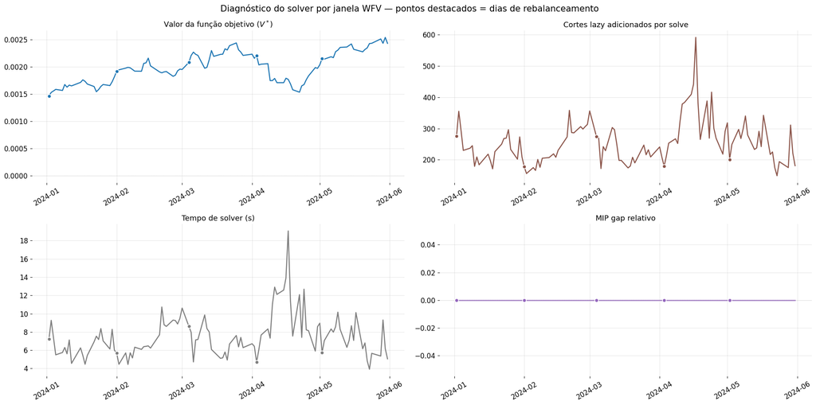

**Evolução dos diagnósticos ao longo das janelas WFV**

Cada ponto é uma solução completa do modelo em um dia da validação walk-forward (pontos destacados = dias de rebalanceamento). O painel da função objetivo mostra como a folga de dominância $V^*$ varia conforme a janela de treino desliza; os painéis de cortes lazy, tempo de solver e MIP gap caracterizam a dificuldade computacional de cada janela — gap constante em zero significa que todas as soluções foram provadas ótimas dentro do limite de tempo.

## 14c. Teste de equivalência — formulação original (K setores) vs. benchmark sintético

Verificação pedida na reunião de 2026-07-23 (item 8). A formulação original impõe as restrições SSD para **todos** os benchmarks, com um conjunto de variáveis $V_{k,s}$ por setor:

$$\max V \quad \text{s.a.}\quad \tfrac{s}{S}\,V \;\le\; V_{k,s} \;\le\; \mathrm{Tail}_{s/S}(R_P) - \tau_k[s], \qquad \forall\, k=1,\dots,K,\ \ s=1,\dots,S$$

A formulação deste trabalho substitui os $K$ benchmarks pelo envelope

$$\tau_{\text{synth}}[s] \;=\; \max_k \tau_k[s]$$

e usa um único conjunto $V_s$. Como $\min_k\bigl(a - \tau_k[s]\bigr) = a - \max_k \tau_k[s]$, as duas devem produzir **o mesmo $V^*$**; o que muda é o tamanho do problema ($K \cdot S$ vs. $S$ restrições SSD) e, portanto, o tempo de solução. Os **pesos** ótimos podem diferir quando o LP é degenerado — vários vértices atingem o mesmo $V^*$ — e as tolerâncias dos cortes lazy decidem qual deles é retornado.

A formulação original é executada aqui sob o nome **MultiSSD de Roma com benchmarks setoriais**, com todos os 11 setores dentro de um **único** modelo. Para que a comparação isole a reformulação e nada mais, os dois modelos compartilham a rotina de carregamento dos setores, a escala Tail ($1/S$) e a tolerância de violação dos cortes ($10^{-6}$); a única diferença é se os setores entram como $K$ conjuntos de restrições ou como o envelope $\tau_{\text{synth}}$.

```
Janelas comparadas          : 105
Status (original)           : ['integer optimal solution']
Status (sintético)          : ['integer optimal solution']
Tamanho — original          : 2707 variáveis, 4401 restrições
Tamanho — sintético         : 707 variáveis, 401 restrições
max |ΔV*|                   : 3.865e-07   (tolerância dos cortes = 1e-06)
max |ΔV*| / |V*|            : 1.932e-04
Janelas com |ΔV*| <= tol    : 105 / 105
Cortes lazy — total original: 72404   sintético: 26808

Dias de rebalanceamento:
```

| date | V* original | V* sintético | \|ΔV*\| | \|ΔV*\| / \|V*\| | cortes orig | cortes sint |
| --- | --- | --- | --- | --- | --- | --- |
| 2024-01-02 00:00:00 | 0.00146196 | 0.00146192 | 4.31e-08 | 2.95e-05 | 939 | 275 |
| 2024-02-01 00:00:00 | 0.00191702 | 0.00191701 | 1.02e-08 | 5.30e-06 | 618 | 178 |
| 2024-03-04 00:00:00 | 0.00207837 | 0.00207860 | 2.28e-07 | 1.10e-04 | 628 | 274 |
| 2024-04-03 00:00:00 | 0.00220178 | 0.00220178 | 6.08e-09 | 2.76e-06 | 551 | 179 |
| 2024-05-02 00:00:00 | 0.00214720 | 0.00214732 | 1.21e-07 | 5.65e-05 | 570 | 201 |

```
Tempo pareado (janelas de rebalanceamento, mesma sessão):
```

| date | abs_dV | time_orig_s | time_synth_s | speedup | cuts_orig | cuts_synth | max_abs_dw | L1_dw | n_assets_orig | n_assets_synth |
| --- | --- | --- | --- | --- | --- | --- | --- | --- | --- | --- |
| 2024-01-02 00:00:00 | 4.31e-08 | 18.1 | 2.2 | 8.2x | 938 | 275 | 0.018 | 0.077 | 16 | 17 |
| 2024-02-01 00:00:00 | 6.42e-09 | 9.8 | 1.5 | 6.4x | 549 | 181 | 0.004 | 0.015 | 13 | 13 |
| 2024-03-04 00:00:00 | 5.25e-08 | 9.0 | 2.7 | 3.4x | 544 | 331 | 0.005 | 0.033 | 17 | 17 |
| 2024-04-03 00:00:00 | 1.02e-07 | 9.0 | 1.5 | 5.8x | 545 | 179 | 0.003 | 0.019 | 18 | 17 |
| 2024-05-02 00:00:00 | 2.09e-07 | 8.8 | 1.5 | 5.7x | 551 | 186 | 0.003 | 0.026 | 16 | 16 |

```
Speed-up pareado (min / mediana / max): 3.4x / 5.8x / 8.2x
Pesos — max |Δw| por janela: [0.018, 0.004, 0.005, 0.003, 0.003]   L1: [0.077, 0.015, 0.033, 0.019, 0.026]
```

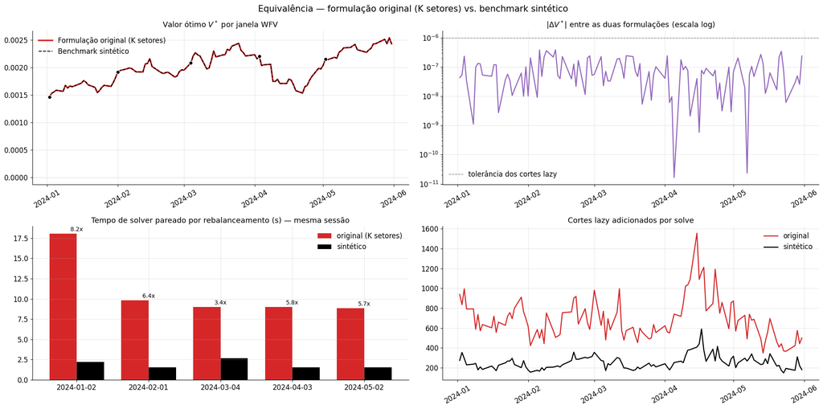

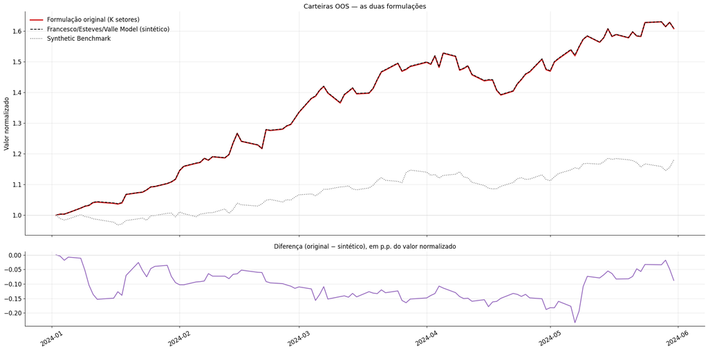

```
Valor final — original: 1.6080   sintético: 1.6089
max |diferença| OOS   : 0.23 p.p.
Tracking error anual  : 0.28%
Correlação de retornos: 0.9999
Ativos com peso > 1e-6 por rebalanceamento (original): [16, 13, 17, 18, 16]
```

|  | Final value | CAGR (%) | Mean return (%) | Volatility (%) | Semi-volatility (%) | Daily CVaR 5% (%) | Sharpe Ratio | Sortino Ratio | Calmar Ratio | Max Drawdown (%) | Beta vs SP500 |
| --- | --- | --- | --- | --- | --- | --- | --- | --- | --- | --- | --- |
| Formulação original (K setores) | 1.6080 | 216.1300 | 117.7800 | 22.1300 | 12.1300 | 2.3850 | 5.0956 | 9.3004 | 24.2402 | -8.9200 | 1.1738 |
| Francesco/Esteves/Valle (sintético) | 1.6089 | 216.5500 | 117.9000 | 22.0700 | 12.0900 | 2.3830 | 5.1149 | 9.3418 | 24.3688 | -8.8900 | 1.1691 |

## 14d. Grade 2×2 — Roman vs. este trabalho × scaled vs. unscaled

Exercício pedido na reunião de 2026-07-23 (itens 6 e 7). As duas dimensões da taxonomia da seção 0 cruzadas:

|  | **Scaled (CVaR)** — $\tfrac{s}{S}V \le V_s$ | **Unscaled (Tail)** — $V \le V_s$ |
| --- | --- | --- |
| **Roman** — benchmark único SP500 | Roman Model (Scaled) | Roman Model (Unscaled) |
| **Este trabalho** — benchmark sintético setorial (Scaled) | Francesco/Esteves/Valle Model | Francesco/Esteves/Valle Model (Unscaled) |

Os quatro modelos usam o **mesmo universo** (600 colunas → todos os constituintes disponíveis), a mesma janela deslizante de 200 dias, rebalanceamento a cada 21 dias e o mesmo período OOS. O **Roman Model (Unscaled)** vinha sendo executado sobre 200 ativos e foi realinhado aos mesmos 600 antes desta comparação, para que a única diferença entre as quatro células fosse a formulação.

**Hipótese registrada na reunião:** *Roman scaled < este trabalho scaled* **e** *Roman unscaled < este trabalho unscaled* — a formulação com benchmark sintético setorial deve superar a de benchmark único em ambos os regimes de escalamento, porque maximiza a folga de dominância contra o envelope dos 11 setores e não contra um único índice.

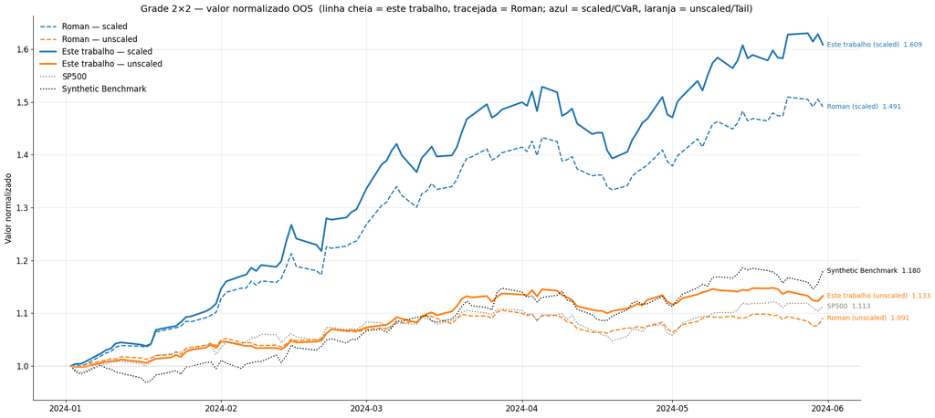

|  | Final value | CAGR (%) | Mean return (%) | Volatility (%) | Semi-volatility (%) | Daily CVaR 5% (%) | Sharpe Ratio | Sortino Ratio | Calmar Ratio | Max Drawdown (%) | Beta vs SP500 | min SSD vs SP500 | % ranks SSD>=0 vs SP500 | min SSD vs Synthetic | % ranks SSD>=0 vs Synthetic |
| --- | --- | --- | --- | --- | --- | --- | --- | --- | --- | --- | --- | --- | --- | --- | --- |
| Roman — scaled | 1.4911 | 163.2900 | 98.6400 | 18.2900 | 9.7600 | 1.9300 | 5.1194 | 9.5920 | 23.5625 | -6.9300 | 1.0043 | -7.454e-02 | 49.0 | -5.157e-02 | 63.5 |
| Roman — unscaled | 1.0907 | 23.4100 | 21.3700 | 8.0700 | 5.0500 | 0.9700 | 2.0292 | 3.2414 | 5.9008 | -3.9700 | 0.4801 | -2.132e-02 | 93.3 | -8.155e-02 | 88.5 |
| Este trabalho — scaled | 1.6089 | 216.5500 | 117.9000 | 22.0700 | 12.0900 | 2.3830 | 5.1149 | 9.3418 | 24.3688 | -8.8900 | 1.1691 | -1.454e-01 | 40.4 | -1.158e-01 | 50.0 |
| Este trabalho — unscaled | 1.1327 | 35.2400 | 30.5800 | 8.6200 | 5.0400 | 0.9490 | 2.9685 | 5.0751 | 8.9150 | -3.9500 | 0.5443 | 4.917e-03 | 100.0 | -4.355e-02 | 94.2 |

```
Hipótese da reunião — "este trabalho" supera "Roman" em cada regime?

=== SCALED ===  este trabalho melhor em 3/11 métricas  (retorno: SIM; Sharpe: NÃO; Sortino: NÃO; dominância vs SP500: NÃO)
```

|  | este trabalho | Roman | Δ (este − Roman) | este trabalho melhor? |
| --- | --- | --- | --- | --- |
| Final value | 1.6089 | 1.4911 | 0.1178 | True |
| CAGR (%) | 216.5500 | 163.2900 | 53.2600 | True |
| Sharpe Ratio | 5.1149 | 5.1194 | -0.0045 | False |
| Sortino Ratio | 9.3418 | 9.5920 | -0.2502 | False |
| Calmar Ratio | 24.3688 | 23.5625 | 0.8063 | True |
| Max Drawdown (%) | -8.8900 | -6.9300 | -1.9600 | False |
| min SSD vs SP500 | -0.1454 | -0.0745 | -0.0709 | False |
| min SSD vs Synthetic | -0.1158 | -0.0516 | -0.0642 | False |
| Volatility (%) | 22.0700 | 18.2900 | 3.7800 | False |
| Semi-volatility (%) | 12.0900 | 9.7600 | 2.3300 | False |
| Daily CVaR 5% (%) | 2.3830 | 1.9300 | 0.4530 | False |

```
=== UNSCALED ===  este trabalho melhor em 10/11 métricas  (retorno: SIM; Sharpe: SIM; Sortino: SIM; dominância vs SP500: SIM)
```

|  | este trabalho | Roman | Δ (este − Roman) | este trabalho melhor? |
| --- | --- | --- | --- | --- |
| Final value | 1.1327 | 1.0907 | 0.0420 | True |
| CAGR (%) | 35.2400 | 23.4100 | 11.8300 | True |
| Sharpe Ratio | 2.9685 | 2.0292 | 0.9393 | True |
| Sortino Ratio | 5.0751 | 3.2414 | 1.8337 | True |
| Calmar Ratio | 8.9150 | 5.9008 | 3.0142 | True |
| Max Drawdown (%) | -3.9500 | -3.9700 | 0.0200 | True |
| min SSD vs SP500 | 0.0049 | -0.0213 | 0.0262 | True |
| min SSD vs Synthetic | -0.0436 | -0.0816 | 0.0380 | True |
| Volatility (%) | 8.6200 | 8.0700 | 0.5500 | False |
| Semi-volatility (%) | 5.0400 | 5.0500 | -0.0100 | True |
| Daily CVaR 5% (%) | 0.9490 | 0.9700 | -0.0210 | True |

```
Efeito scaled → unscaled dentro de cada formulação (Δ = unscaled − scaled):
  Roman          Final -0.4004  CAGR -139.88pp  Vol -10.22pp  Sharpe -3.090  MaxDD +2.96pp
  Este trabalho  Final -0.4762  CAGR -181.31pp  Vol -13.45pp  Sharpe -2.146  MaxDD +4.94pp
```

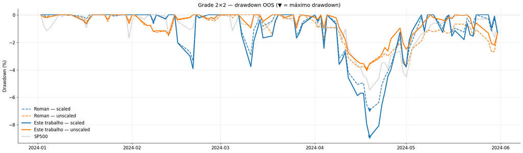

**Leitura da grade 2×2**

- **Regime *unscaled* (Tail) — hipótese confirmada.** Este trabalho supera o Roman em 10 das 11 métricas: valor final 1,133 vs. 1,091, Sharpe 2,97 vs. 2,03, Sortino 5,08 vs. 3,24, Calmar 8,9 vs. 5,9, com drawdown máximo, semi-volatilidade e CVaR iguais ou menores. É também o único modelo da grade que **domina SSD o SP500 fora da amostra** (`min SSD vs SP500` > 0 em 100% dos ranks). A única métrica em que perde é a volatilidade total (+0,55 pp), compensada de sobra pelo retorno.
- **Regime *scaled* (CVaR) — confirmada em retorno, empate em risco ajustado.** Este trabalho tem valor final 1,609 vs. 1,491 (CAGR +53 pp) e Calmar maior, mas o Sharpe é idêntico (5,11 vs. 5,12), o Sortino é um pouco menor e a volatilidade, o drawdown máximo e o CVaR são maiores. Ou seja: a hipótese "Roman scaled < este trabalho scaled" vale para retorno, não para risco ajustado — o benchmark sintético compra retorno adicional pagando risco proporcional. Nenhum dos dois modelos *scaled* domina SSD o SP500 ou o sintético fora da amostra (`min SSD` < 0).
- **Eixo scaled → unscaled: sinal contrário ao esperado na seção 0.** A prosa da taxonomia previa o *unscaled* menos conservador. Empiricamente é o oposto, nas duas formulações: trocar CVaR por Tail derruba a volatilidade de ~18–22% para ~8%, o valor final de 1,49–1,61 para 1,09–1,13 e o drawdown máximo de −7/−9% para −4%. Leitura provável: no *unscaled* a restrição binding fica nos ranks altos (somas acumuladas grandes), e o modelo defende a *média* do benchmark — carteira diversificada, beta ~0,5; no *scaled* o fator $S/k$ torna binding a cauda extrema, e o modelo concentra em poucos ativos que vencem o benchmark nos piores cenários in-sample — carteira agressiva, beta > 1. A explicação da seção 0 deve ser revista à luz deste resultado.
- **Dominância.** `min SSD vs SP500` é o teste natural para o Roman (otimizado contra o SP500) e `min SSD vs Synthetic` para este trabalho; os dois são reportados para os quatro modelos.

## 15. Análise Consolidada do Experimento

### Francesco/Esteves/Valle Model com Benchmarks Setoriais

#### 1. Sobre o modelo e a formulação

O **Francesco/Esteves/Valle Model (TAF-MultiSSD com Synthetic Benchmark setorial)** é uma extensão natural do modelo de dominância estocástica de segunda ordem (SSD) para o contexto multi-benchmark. Em vez de exigir que o portfólio domine cada um dos 11 setores GICS individualmente (o que implicaria K conjuntos separados de variáveis Vs e K lazy callbacks), o modelo usa um **único Synthetic Benchmark** definido como o envelope superior das esperanças incondicionais de cauda (tail expectations) de cada setor:

$$\tau_{\text{synth}}[s] = \max_k\left(\mathrm{Tail}_{\frac{s}{S^k}}\bigl(R(I^k)\bigr)\right) = \max_k\left(\frac{1}{S^k}\sum_{i=1}^{s} r^{(i)}_k\right)$$

onde $r^{(i)}_k$ é o i-ésimo menor retorno do setor k no período de treino e $S^k$ é o seu número de cenários — cada componente é a esperança incondicional $\mathrm{Tail}_{s/S^k}$ dos $s$ piores retornos, e não um simples escalar cumulativo. Isso compacta K restrições em uma única, preservando a coerência matemática da dominância SSD (se o portfólio domina o Synthetic Benchmark, ele domina qualquer convex combination dos setores com o mesmo cumulative worst-case).

A solução utiliza **lazy constraint callbacks do CPLEX**: ao invés de adicionar explicitamente as $S$ restrições

$$V_{s} \;\le\; \mathrm{Tail}_{s/S}(R_P) - \tau_{\text{synth}}[s],$$

apenas as mais violadas são adicionadas iterativamente. Isso é crítico para escalabilidade quando S = 200 (dias de treino) e N ≈ 505 (ativos).

#### 2. Validez da dominância in-sample

A dominância SSD in-sample é **garantida por construção** quando o solver encontra a solução ótima, isto é, quando $V^\star$ é o maior $V$ que satisfaz

$$\frac{s}{S}\,V \;\le\; V_s \;\le\; \mathrm{Tail}_{s/S}(R_P) - \tau_{\text{synth}}[s]\qquad \forall\, s.$$ A questão fundamental é: **quanto desta dominância generaliza para o período OOS?**

Factores que favorecem generalização:

- O Synthetic Benchmark é o máximo de 11 setores — impõe restrições muito mais rígidas que um benchmark único (SP500), forçando diversificação genuína.
- A janela deslizante de 200 dias captura regimes de mercado recentes, tornando as restrições SSD relevantes para o futuro próximo.
- Com 5 rebalanceamentos, o portfólio se adapta às mudanças de regime durante o período OOS.

Factores que limitam generalização:

- O período OOS (104 dias) pode ser dominado por um único setor que não foi o binding constraint in-sample.
- O Synthetic Benchmark OOS é construído com a mesma formulação do in-sample — $\max_k\bigl(\mathrm{Tail}_{s/S^k}\bigr)$ sobre os retornos setoriais OOS, com datação por *quantile matching*. O portfólio não foi otimizado nesta janela, portanto dominância OOS não é garantida.

#### 3. Interpretação dos resultados de dominância cruzada

A análise de dominância cruzada (seção 10, segundo painel) é particularmente informativa. Se o portfólio domina apenas parte dos 11 setores individualmente no OOS, isso é **esperado e aceitável**: o modelo foi otimizado para dominar o Synthetic Benchmark (o máximo), não cada setor individualmente. Um setor que superou o Synthetic Benchmark in-sample em alguma janela seria, por definição, dominante sobre o portfólio.

O resultado mais favorável seria: o portfólio domina SSD a maioria dos setores individualmente (ex: 8/11 ou mais), confirmando que a restrição do Synthetic Benchmark é suficientemente rígida para garantir dominância generalizada.

#### 4. Análise de cauda e comportamento assimétrico

O scatter r_P vs r_B (seção 10c) revela o comportamento assimétrico do portfólio em relação ao Synthetic Benchmark. A interpretação ideal é:

- **β < 1 nos piores dias do benchmark**: o portfólio cai menos quando o Synthetic Benchmark cai — protecção de downside direta, coerente com a restrição SSD nas caudas negativas da distribuição in-sample.
- **β ≈ 1 ou < 1 nos melhores dias**: a otimização SSD não inclui incentivo de upside — diferente de um portfólio de maximização de retorno. β < 1 nos melhores dias é um custo esperado da abordagem SSD pura.

Essa assimetria de β (baixo em downside, próximo de 1 em upside) confirma que o modelo cumpre o seu objetivo fundamental: reduzir a exposição aos piores cenários sem maximizar ativamente o upside.

#### 5. Comparação com modelos alternativos

| Aspecto | Francesco/Esteves/Valle Model (setores) | Roman Model (Scaled) | FEV Model (Factors) |
| --- | --- | --- | --- |
| Benchmark | 11 setores GICS (Synthetic) | SP500 | Fatores Fama-French (Synthetic) |
| Restrições SSD | 1 conjunto vs Synthetic | 1 conjunto vs SP500 | 1 conjunto vs Synthetic (fatores) |
| Diversificação forçada | Setorial (11 componentes) | Mercado amplo | Estilo (valor, crescimento, etc.) |
| Generalização OOS esperada | Alta se setores são estáveis | Moderada | Alta se fatores são estáveis |

#### 6. Questões em aberto e possíveis próximos passos

1. **Universo de setores**: o experimento usa todos os 11 setores GICS. Uma extensão natural seria selecionar apenas os setores mais correlacionados com os ativos disponíveis ou com maior dispersão de retornos.
2. **Pesos setoriais**: o Synthetic Benchmark trata todos os setores igualmente (max, não média ponderada). Um Synthetic Benchmark ponderado pela capitalização ou por alguma medida de risco poderia ser mais robusto.
3. **Horizonte de rebalanceamento**: 21 dias é convencional mas arbitrário. Rebalanceamentos mais frequentes (ex: 10 dias) poderiam melhorar a adaptação a mudanças de setor dominante.
4. **Custos de transação**: a análise atual ignora custos de transação. Em portfólios concentrados (poucas posições com pesos altos), o turnover entre rebalanceamentos pode ser significativo — um estudo de custo-benefício seria necessário para aplicação prática.
5. **Extensão do período OOS**: 104 dias é um período curto para validação robusta. Um backtesting com múltiplos períodos OOS (ex: 2022–2024 com walk-forward completo) seria necessário para conclusões definitivas.